```python
#Load libraries

import pandas as pd
import nltk
import matplotlib.pyplot as plt
import seaborn as sns
import pprint

import numpy as np
from sklearn import preprocessing, decomposition, model_selection, metrics, pipeline
from sklearn.model_selection import GridSearchCV
from sklearn.feature_extraction.text import TfidfVectorizer, CountVectorizer
from sklearn.model_selection import train_test_split


from sklearn.decomposition import TruncatedSVD
from sklearn.linear_model import LogisticRegression

from sklearn.naive_bayes import MultinomialNB
import xgboost as xgb
from sklearn import metrics

import spacy
```

# Victorian Authoriship Attribution

The dataset has been sourced from the machine learning repository

https://archive.ics.uci.edu/ml/datasets/Victorian+Era+Authorship+Attribution

citation: GUNGOR, ABDULMECIT, Benchmarking Authorship Attribution Techniques Using Over A Thousand Books by Fifty Victorian Era Novelists, Purdue Master of Thesis, 2018-04

### Introduction

Authorship Attribution is the process of attempting to identity the likely author based on a collection of documents whose authorship is known. I plan to investigate the use of machine learning techniques to identify the author of a document.

The aim is to build a model that can read in a text and suggest which author it is. The model will learn from having learned off seeing the authors work previously. This is a supervised multi class classification problem as there are multiple authors and we have a sample of each author's work for the model to learn from. Given a new piece of work the aim is for the classifier to assign it to one of the author's known by the classifier. In this case the assumption of the classifier will be that each piece of work is assigned to one author.

```python
#load the dataset
```

```python
file_name = '../data/victorian_author_sample_main_authors_train1.csv'
df = pd.read_csv(file_name, encoding="utf-8")
```

If a dataset is present, features and calculated statistics relevant to the problem have been reported and discussed, along with a sampling of the data. In lieu of a dataset, a thorough description of the input space or input data has been made. Abnormalities or characteristics about the data or input that need to be addressed have been identified

## Data Analysis

```python
df.shape[0]
```

```
25101
```

```
Text(0,0.5,'Value Count')
```

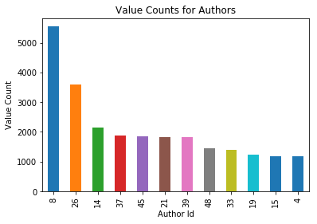

```python
ax = pd.value_counts(df['author'].values).plot(kind="bar", title='Value Counts for Authors')
ax.set_xlabel("Author Id")
ax.set_ylabel("Value Count")
```

```python
#declare variables to make below code cleaner and more generic
OUTPUT_COLUMN = 'author'
TEXT_COLUMN = 'text'
```

```python
print("Rows in data frame: {}".format(df.shape[0]))
print('Columns in data frame')
df.columns
```

```
Rows in data frame: 25101
Columns in data frame
```

```
Index(['text', 'author', 'count'], dtype='object')
```

```python
#review first few rows
df.head()
```

|  | text | author | count |
| --- | --- | --- | --- |
| 0 | towards me and her little fingers round my han... | 8 | 6914 |
| 1 | would hear later the names of their lost dead ... | 39 | 2266 |
| 2 | rules of than any other poem in the language b... | 45 | 2312 |
| 3 | any such visible but there is a grand tendency... | 33 | 1742 |
| 4 | i didn t thought to have left you so the retur... | 4 | 1483 |

```python
df[TEXT_COLUMN][0][:1000]
```

```
'towards me and her little fingers round my hand many and many an hour i sit thus but of all those times three times come the on my mind it is morning and made so trim by my aunt s hands me how her pretty hair will curl upon the pillow yet and how long and bright it is and how she likes to have it l…
```

```python
#How Many Unique authors are there in the dataset
target_values = df[OUTPUT_COLUMN].nunique()
target_values
```

```
12
```

```python
#Prepare the dataset for modelling by splitting out the target variable
targets = df[OUTPUT_COLUMN]
#How many records are there in total
targets.count()
```

```
25101
```

```python
#add column for word count
df['word_count'] = df[TEXT_COLUMN].apply(lambda x: len(x.split(' ')))
```

```python
df['length'] = df[TEXT_COLUMN].apply(len)
```

```python
df.describe()
```

|  | author | count | word_count | length |
| --- | --- | --- | --- | --- |
| count | 25101.000000 | 25101.000000 | 25101.0 | 25101.000000 |
| mean | 23.550018 | 3494.622565 | 1001.0 | 4939.044261 |
| std | 13.749266 | 2019.531330 | 0.0 | 262.495317 |
| min | 4.000000 | 1460.000000 | 1001.0 | 2341.000000 |
| 25% | 8.000000 | 1825.000000 | 1001.0 | 4813.000000 |
| 50% | 21.000000 | 2387.000000 | 1001.0 | 4958.000000 |
| 75% | 37.000000 | 4441.000000 | 1001.0 | 5100.000000 |
| max | 48.000000 | 6914.000000 | 1001.0 | 5696.000000 |

```python
#Prepare the dataset for modelling by splitting into features
print("Dropping the author column from the dataframe ")
features = df.drop(OUTPUT_COLUMN, axis=1)
#remove count column that was added for sampling this essentially identifies the author
features = df.drop('count', axis=1)
features.count()
```

```
Dropping the author column from the dataframe
```

```
text          25101
author        25101
word_count    25101
length        25101
dtype: int64
```

```python
features.head(1)
```

|  | text | author | word_count | length |
| --- | --- | --- | --- | --- |
| 0 | towards me and her little fingers round my han... | 8 | 1001 | 4574 |

## Split into Train and Test Set

It is necessary to check that the distribution of works for each author is roughly the same in each. Stratified sampling by author id is used here because the distribution of works per author is not even in the dataset.

```python
#perform train test split
X_train, X_test, y_train, y_test = train_test_split(features, targets, test_size=0.20,
                                                    random_state=42, stratify=targets)
```

```python
#Print sizes of train and test
print('train  = ',  X_train.shape)
print('test  = ',  X_test.shape)
```

```
train  =  (20080, 4)
test  =  (5021, 4)
```

```python
X_train.head()
```

|  | text | author | word_count | length |
| --- | --- | --- | --- | --- |
| 1843 | die repeating these words like quick of fury h... | 33 | 1001 | 4894 |
| 1995 | killed not half a mile from here if ye will ac... | 39 | 1001 | 4777 |
| 4438 | me most admirably has really proved an invalua... | 26 | 1001 | 5220 |
| 16993 | workings of fancy gracious heaven i said the m... | 8 | 1001 | 5077 |
| 5995 | showed proper respect to me to me sir said mr ... | 8 | 1001 | 4853 |

### Confirm that train and test contain roughly the same distribution of authors

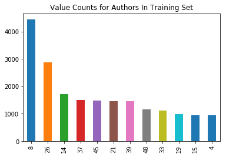

```python
pd.value_counts(y_train).plot(kind="bar", title='Value Counts for Authors In Training Set')
```

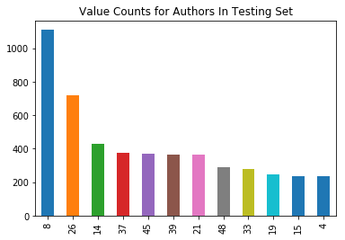

```python
pd.value_counts(y_test).plot(kind="bar", title='Value Counts for Authors In Testing Set')
```

## Initial Preprocessing

The model can not process text so the text must be vectorised to a numeric grid.

The two main options to numericialse text are a bag of words model or term inverse document frequency

Here the process being used is Term inverse document frequency

The idea of tf-idf is to find the important words for the content of each document by decreasing the weight for commonly used words and increasing the weight for words that are not used very much in a collection or corpus of documents

```python
#Pre-process text in order to feed it into machine learning models
#Define term inverse document frequency vectorizer
#Using TFIDF also allows me to ignore the problem of stop words (common words in the text)
#By setting stop words to english TFIDF vectorizer will ignore stop words


#Minimum Document Frequency - states what is the minimum number of documents a term must be found in
min_df = 1 #Term must appear in at least one document
#Maximum Document Frequency - states what is the maximum number of documents a term must be found in
max_df = 25 # ignore terms that appear in more than 25 documents
max_features = 100
#ngram range = The lower and upper boundary of the range of n-values for different n-grams to be extracted
#eg ngram_range (1,2) extracts up to bigrams

tfidf_vectorizer = TfidfVectorizer(stop_words='english', min_df=min_df, max_df=max_df, ngram_range=(1,2), max_features=max_features)
```

```python
#Fit TFIDF vectorizer to the test and the training set
#in this step the vocuabulary of the training data is learned

tfidf_vectorizer.fit(X_train[TEXT_COLUMN])
#get document term matrix for the training set
X_train_tfidf =  tfidf_vectorizer.transform(X_train[TEXT_COLUMN])
#get document term matrix for the test set
X_test_tfidf = tfidf_vectorizer.transform(X_test[TEXT_COLUMN])
```

### Examine the Vocabulary of the corpus

Many of the key terms extracted appear to be potentially characters in the text

```python
feature_names = tfidf_vectorizer.get_feature_names()
print("Feature Names Generated from Inverse Term Frequency model")
print(feature_names[:50])
```

```
Feature Names Generated from Inverse Term Frequency model
['amateur night', 'aunt mary', 'bending bough', 'benefit doubt', 'big fat', 'black jack', 'blind girl', 'break day', 'brother francis', 'brother ned', 'chief butler', 'class struggle', 'colonel wife', 'drum horse', 'drums fore', 'edition cr', 'ev ev', 'faith men', 'fat boy', 'father peter', 'father …
```

```python
train_tfidf_df = pd.DataFrame(X_train_tfidf.toarray(), columns=feature_names)
```

```python
train_tfidf_df.head()
```

|  | amateur night | aunt mary | bending bough | benefit doubt | big fat | black jack | blind girl | break day | brother francis | brother ned | ... | troop horse | true thomas | ward th | ward valley | ward ward | whale tooth | william conqueror | wonderful wife | years date | yellow handkerchief |
| --- | --- | --- | --- | --- | --- | --- | --- | --- | --- | --- | --- | --- | --- | --- | --- | --- | --- | --- | --- | --- | --- |
| 0 | 0.0 | 0.0 | 0.0 | 0.0 | 0.0 | 0.0 | 0.0 | 0.0 | 0.0 | 0.0 | ... | 0.0 | 0.0 | 0.0 | 0.0 | 0.0 | 0.0 | 0.0 | 0.0 | 0.0 | 0.0 |
| 1 | 0.0 | 0.0 | 0.0 | 0.0 | 0.0 | 0.0 | 0.0 | 0.0 | 0.0 | 0.0 | ... | 0.0 | 0.0 | 0.0 | 0.0 | 0.0 | 0.0 | 0.0 | 0.0 | 0.0 | 0.0 |
| 2 | 0.0 | 0.0 | 0.0 | 0.0 | 0.0 | 0.0 | 0.0 | 0.0 | 0.0 | 0.0 | ... | 0.0 | 0.0 | 0.0 | 0.0 | 0.0 | 0.0 | 0.0 | 0.0 | 0.0 | 0.0 |
| 3 | 0.0 | 0.0 | 0.0 | 0.0 | 0.0 | 0.0 | 0.0 | 0.0 | 0.0 | 0.0 | ... | 0.0 | 0.0 | 0.0 | 0.0 | 0.0 | 0.0 | 0.0 | 0.0 | 0.0 | 0.0 |
| 4 | 0.0 | 0.0 | 0.0 | 0.0 | 0.0 | 0.0 | 0.0 | 0.0 | 0.0 | 0.0 | ... | 0.0 | 0.0 | 0.0 | 0.0 | 0.0 | 0.0 | 0.0 | 0.0 | 0.0 | 0.0 |

5 rows × 100 columns

```python
train_tfidf_df.shape
```

```
(20080, 100)
```

```python
y_train.shape
```

```
(20080,)
```

## Evaluation Metrics

### Log Loss

Evaluates the confidence of membership to a given class or in this case the work belonging to a particular author. For example the model calculates a probability that the work belongs to a particular author. The log loss metric will decrease as the model predicts a probability close to the true value.

For clarity the formula is as follows: (-1/N) (sum from i = 1 to N ai) (sum from j = 1 to M aj) yij, log(pij)

```python
#code to visualise the results of machine learning models
import seaborn as sns
def visualise_model_results(output_df):
    sns.boxplot(x='model_name', y='neg_log_loss', data=output_df).set_title('Model Results')
```

```python
%timeit
#Function to run Models
from sklearn.model_selection import cross_val_score
from sklearn.linear_model import LogisticRegression
from sklearn.ensemble import RandomForestClassifier
from sklearn.svm import LinearSVC
from sklearn.model_selection import cross_val_score


def run_models(models, CV, x_train, y_train) :

    entries = []

    for model in models:
          model_name = model.__class__.__name__
         #Obtain cross val score.
          log_losses = cross_val_score(model, x_train, y_train, scoring='neg_log_loss', cv=CV)

        #create a list of results
          for fold_idx, log_loss in enumerate(log_losses):
               entries.append((model_name, fold_idx, log_loss))

    cv_df = pd.DataFrame(entries, columns=['model_name', 'fold_idx', 'neg_log_loss'])

    return cv_df
```

## Run Baseline Models

```python
#defining a function to save the model after it has been trained using .fit
def storeModel(model, filename):
     joblib.dump(model, filename)
```

```python
#defining a funtion the restore the model that has been previously trained
def restoreModel(filename):
    loaded_model = joblib.load(filename)
    return loaded_model
```

### Run Models and obtain cross validation score

```python
%%time
CV = 5

#Random forest was removed from the list of classifers run because the results were well below the
#other classifiers

models = [

         xgb.XGBClassifier(max_depth=7, n_estimators=100, colsample_bytree=0.8,
                        subsample=0.8, nthread=10, learning_rate=0.1),
        LogisticRegression(random_state=0),
        MultinomialNB()
 ]
output_df  = run_models(models, CV, X_train_tfidf, y_train)
```

```
Wall time: 21.1 s
```

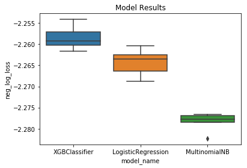

```python
visualise_model_results(output_df)
```

```python
output_df.head(10)
```

|  | model_name | fold_idx | neg_log_loss |
| --- | --- | --- | --- |
| 0 | XGBClassifier | 0 | -2.254163 |
| 1 | XGBClassifier | 1 | -2.260237 |
| 2 | XGBClassifier | 2 | -2.259296 |
| 3 | XGBClassifier | 3 | -2.257070 |
| 4 | XGBClassifier | 4 | -2.261655 |
| 5 | LogisticRegression | 0 | -2.262463 |
| 6 | LogisticRegression | 1 | -2.266374 |
| 7 | LogisticRegression | 2 | -2.263525 |
| 8 | LogisticRegression | 3 | -2.260379 |
| 9 | LogisticRegression | 4 | -2.268761 |

## Feature Engineering

The baseline results are not good ideally log loss needs to be near zero. TFIDF gives the importance of terms in this case bigrams in a sample of text relative to the other samples of text in the dataset. TFIDF could be useful in a classification task where it needs to identify documents that share a similar topic. For works belonging to one author it may not always be the case that the topics are similar.

For this reason I have choosen to attempt to engineer features focusing on structures of speech to see if it is possible to learn more about each authors style

Because of Processing Time I have processed the entire dataset in another notebook and load it in here using a csv file rather than using an sklearn pipeline

### Load Dataset Containing Part of Speech Features

```python
#load data set which has been tagged with parts of speech (code is available in another notebook)
file_name = '../IntermediateData/victorian_author_sample_main_authors_train1_postag_25101_final.csv'
df_pos = pd.read_csv(file_name, encoding="utf-8")
```

```python
#preview dataset
df_pos.head(2)
```

|  | text | author | count | length | sentence_counter | ADJ | ADP | ADV | CCONJ | DET | ... | PRON | PROPN | PUNCT | SYM | VERB | X | av_noun | av_verb | av_pron | av_adj |
| --- | --- | --- | --- | --- | --- | --- | --- | --- | --- | --- | --- | --- | --- | --- | --- | --- | --- | --- | --- | --- | --- |
| 0 | illumination of hope in any case i shall remai... | 14 | 2696 | 1001 | 36 | 114 | 148 | 68.0 | 33 | 90 | ... | 106 | 0.0 | 1.0 | 0.0 | 207 | 14.0 | 5.000000 | 5.750000 | 2.944444 | 3.166667 |
| 1 | you want to sing the first part of the act lan... | 15 | 1460 | 1001 | 35 | 101 | 153 | 64.0 | 41 | 96 | ... | 136 | 0.0 | 0.0 | 0.0 | 221 | 3.0 | 4.542857 | 6.314286 | 3.885714 | 2.885714 |

2 rows × 24 columns

### Visualising Features

Exploring the part of speech tags

```
Text(0,0.5,'Average Sentence Count')
```

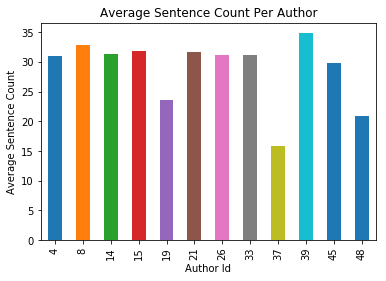

```python
#average sentence count per author
average_sentence_count = df_pos['sentence_counter'].groupby(df_pos[OUTPUT_COLUMN])
ax = average_sentence_count.mean().plot(kind="bar", title='Average Sentence Count Per Author')
ax.set_xlabel("Author Id")
ax.set_ylabel("Average Sentence Count")
```

```
Text(0,0.5,'Noun Count')
```

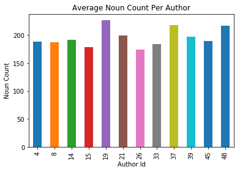

```python
#average noun count per author
average_noun_count = df_pos['NOUN'].groupby(df_pos[OUTPUT_COLUMN])
ax = average_noun_count.mean().plot(kind="bar", title='Average Noun Count Per Author')
ax.set_xlabel("Author Id")
ax.set_ylabel("Noun Count")
```

```
Text(0,0.5,'Average Verb Count')
```

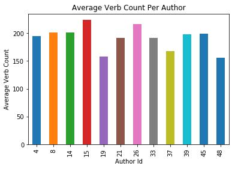

```python
#average noun count per author
average_verb_count = df_pos['VERB'].groupby(df_pos[OUTPUT_COLUMN])
ax = average_verb_count.mean().plot(kind="bar", title='Average Verb Count Per Author')
ax.set_xlabel("Author Id")
ax.set_ylabel("Average Verb Count")
```

```
Text(0,0.5,'Average Adverb Count')
```

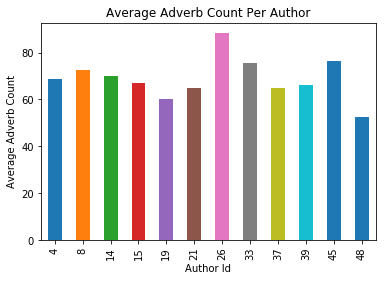

```python
#average noun count per author
average_adverb_count = df_pos['ADV'].groupby(df_pos[OUTPUT_COLUMN])
ax = average_adverb_count.mean().plot(kind="bar", title='Average Adverb Count Per Author')
ax.set_xlabel("Author Id")
ax.set_ylabel("Average Adverb Count")
```

```python
#add column for word count
df_pos['word_count'] = df_pos[TEXT_COLUMN].apply(lambda x: len(x.split(' ')))
```

```python
df_pos['length'] = df_pos[TEXT_COLUMN].apply(len)
```

```python
#remove correlated features which will impact the model and text column which the model can't handle
#I have not used spearmanR to determine correlation in this instance, I know the count variable is directly
#related to the author as it was used for sampling and the av parts of speech were calcaulated using the
#parts of speech so leaving them in would in essense be using them twice.

cols_to_drop = ['count', 'text', 'av_noun', 'av_verb', 'av_pron', 'DET', 'av_adj', 'X']
df_pos_model = df_pos.drop(cols_to_drop, axis=1)
                            # remove the text the models won't like it
```

```python
df_pos_model.head(1)
```

|  | author | length | sentence_counter | ADJ | ADP | ADV | CCONJ | INTJ | NOUN | NUM | PART | PRON | PROPN | PUNCT | SYM | VERB | word_count |
| --- | --- | --- | --- | --- | --- | --- | --- | --- | --- | --- | --- | --- | --- | --- | --- | --- | --- |
| 0 | 14 | 4968 | 36 | 114 | 148 | 68.0 | 33 | 3.0 | 180 | 4.0 | 33 | 106 | 0.0 | 1.0 | 0.0 | 207 | 1001 |

```python
#inspect how many rows and columns there are
df_pos_model.shape
```

```
(25101, 17)
```

```python
pos_authors = df_pos_model['author']
pos_authors.count()
```

```
25101
```

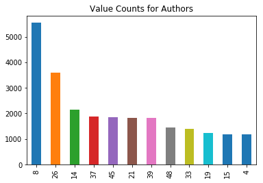

```python
pd.value_counts(pos_authors).plot(kind="bar", title='Value Counts for Authors')
```

```python
pos_features = df_pos_model.drop('author', axis = 1)
```

```python
#inspect features
pos_features.columns
```

```
Index(['length', 'sentence_counter', 'ADJ', 'ADP', 'ADV', 'CCONJ', 'INTJ',
       'NOUN', 'NUM', 'PART', 'PRON', 'PROPN', 'PUNCT', 'SYM', 'VERB',
       'word_count'],
      dtype='object')
```

```python
#fill empty values
pos_features= pos_features.fillna(value=0)
```

```python
pos_features.head(20)
```

|  | length | sentence_counter | ADJ | ADP | ADV | CCONJ | INTJ | NOUN | NUM | PART | PRON | PROPN | PUNCT | SYM | VERB | word_count |
| --- | --- | --- | --- | --- | --- | --- | --- | --- | --- | --- | --- | --- | --- | --- | --- | --- |
| 0 | 4968 | 36 | 114 | 148 | 68.0 | 33 | 3.0 | 180 | 4.0 | 33 | 106 | 0.0 | 1.0 | 0.0 | 207 | 1001 |
| 1 | 5024 | 35 | 101 | 153 | 64.0 | 41 | 2.0 | 159 | 1.0 | 24 | 136 | 0.0 | 0.0 | 0.0 | 221 | 1001 |
| 2 | 5254 | 14 | 85 | 174 | 64.0 | 37 | 0.0 | 206 | 5.0 | 28 | 59 | 3.0 | 0.0 | 0.0 | 194 | 1001 |
| 3 | 4933 | 34 | 140 | 129 | 59.0 | 41 | 3.0 | 235 | 10.0 | 15 | 89 | 0.0 | 3.0 | 0.0 | 179 | 1001 |
| 4 | 2777 | 191 | 35 | 59 | 14.0 | 13 | 30.0 | 413 | 7.0 | 6 | 85 | 46.0 | 11.0 | 3.0 | 69 | 1001 |
| 5 | 4632 | 53 | 86 | 124 | 58.0 | 27 | 5.0 | 183 | 11.0 | 31 | 127 | 1.0 | 1.0 | 0.0 | 230 | 1001 |
| 6 | 5139 | 29 | 113 | 156 | 58.0 | 43 | 0.0 | 195 | 5.0 | 28 | 103 | 2.0 | 1.0 | 0.0 | 205 | 1001 |
| 7 | 4875 | 42 | 108 | 154 | 81.0 | 30 | 2.0 | 173 | 5.0 | 24 | 119 | 0.0 | 3.0 | 0.0 | 199 | 1001 |
| 8 | 4951 | 18 | 111 | 135 | 78.0 | 49 | 1.0 | 191 | 9.0 | 17 | 77 | 3.0 | 1.0 | 0.0 | 201 | 1001 |
| 9 | 4869 | 45 | 103 | 129 | 79.0 | 47 | 1.0 | 175 | 1.0 | 22 | 134 | 1.0 | 1.0 | 0.0 | 222 | 1001 |
| 10 | 4831 | 48 | 86 | 163 | 70.0 | 48 | 7.0 | 202 | 9.0 | 25 | 86 | 3.0 | 0.0 | 0.0 | 207 | 1001 |
| 11 | 5214 | 14 | 114 | 207 | 42.0 | 47 | 2.0 | 198 | 2.0 | 21 | 40 | 0.0 | 1.0 | 0.0 | 164 | 1001 |
| 12 | 5058 | 31 | 117 | 162 | 56.0 | 42 | 3.0 | 196 | 1.0 | 17 | 105 | 1.0 | 0.0 | 0.0 | 199 | 1001 |
| 13 | 5105 | 28 | 119 | 126 | 106.0 | 40 | 0.0 | 177 | 2.0 | 35 | 111 | 0.0 | 0.0 | 0.0 | 219 | 1001 |
| 14 | 4704 | 45 | 111 | 106 | 53.0 | 56 | 5.0 | 200 | 5.0 | 11 | 138 | 0.0 | 1.0 | 0.0 | 187 | 1001 |
| 15 | 5083 | 21 | 102 | 160 | 64.0 | 55 | 0.0 | 182 | 14.0 | 27 | 83 | 5.0 | 1.0 | 0.0 | 188 | 1001 |
| 16 | 5233 | 24 | 96 | 127 | 84.0 | 46 | 3.0 | 179 | 3.0 | 38 | 95 | 0.0 | 0.0 | 0.0 | 239 | 1001 |
| 17 | 5044 | 23 | 106 | 141 | 77.0 | 36 | 1.0 | 196 | 2.0 | 37 | 81 | 0.0 | 0.0 | 0.0 | 219 | 1001 |
| 18 | 4963 | 14 | 108 | 139 | 60.0 | 54 | 1.0 | 208 | 4.0 | 18 | 73 | 8.0 | 0.0 | 0.0 | 190 | 1001 |
| 19 | 5287 | 5 | 132 | 127 | 71.0 | 83 | 0.0 | 228 | 5.0 | 23 | 34 | 0.0 | 0.0 | 0.0 | 188 | 1001 |

### Split into Test and Training Set

```python
X_train_pos, X_test_pos, y_train_pos, y_test_pos = train_test_split(pos_features, pos_authors, test_size=0.20,
                                                    random_state=42, stratify=pos_authors)
```

```python
#Print sizes of train and test
print('train  = ',  X_train_pos.shape)
print('test  = ',  X_test_pos.shape)
```

```
train  =  (20080, 16)
test  =  (5021, 16)
```

```python
# Get Cross Validation Score for the Models using the new feature set
```

```
Wall time: 53.9 s
```

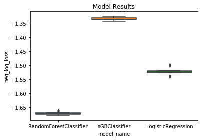

```python
%%time
CV = 5

models = [
        RandomForestClassifier(n_estimators=50, max_depth=7, random_state=0),
        xgb.XGBClassifier(max_depth=7, n_estimators=50, colsample_bytree=0.8,
                        subsample=0.8, nthread=10, learning_rate=0.1),
        LogisticRegression(random_state=0),
        #MultinomialNB() - Multinominal NB was removed because it gives much poorer results compared to other models
 ]
output_df  = run_models(models, CV, X_train_pos, y_train_pos)
visualise_model_results(output_df)
```

```python
output_df.head(10)
```

|  | model_name | fold_idx | neg_log_loss |
| --- | --- | --- | --- |
| 0 | RandomForestClassifier | 0 | -1.661732 |
| 1 | RandomForestClassifier | 1 | -1.678619 |
| 2 | RandomForestClassifier | 2 | -1.674338 |
| 3 | RandomForestClassifier | 3 | -1.669623 |
| 4 | RandomForestClassifier | 4 | -1.672739 |
| 5 | XGBClassifier | 0 | -1.324637 |
| 6 | XGBClassifier | 1 | -1.334694 |
| 7 | XGBClassifier | 2 | -1.341059 |
| 8 | XGBClassifier | 3 | -1.329886 |
| 9 | XGBClassifier | 4 | -1.334707 |

### Feature Importance

```python
def feature_plot(importances, X_train, Y_train):
    indices = np.argsort(importances)[::-1]
    columns = X_train.columns.values[indices[:5]]
    values = importances[indices][:5]

    # Creat the plot
    fig = plt.figure(figsize = (9,5))
    plt.title("Normalized Weights for First Five Most Predictive Features", fontsize = 16)
    plt.bar(np.arange(5), values, width = 0.6, align="center", color = '#00A000', \
          label = "Feature Weight")
    plt.bar(np.arange(5) - 0.3, np.cumsum(values), width = 0.2, align = "center", color = '#00A0A0', \
          label = "Cumulative Feature Weight")
    plt.xticks(np.arange(5), columns)
    plt.xlim((-0.5, 4.5))
    plt.ylabel("Weight", fontsize = 12)
    plt.xlabel("Feature", fontsize = 12)

    plt.legend(loc = 'upper center')
    plt.tight_layout()
    plt.show()
```

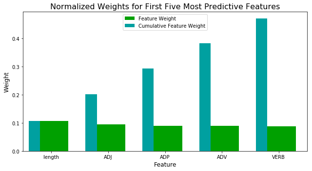

```
Wall time: 17.1 s
```

```python
%%time
clf_XGB = xgb.XGBClassifier(random_state=0, n_estimators = 50, reg_alpha = 1, max_depth=7)

#Train the  model on the training set
model = clf_XGB.fit(X_train_pos, y_train_pos)

# Extract the feature importances
importances = model.feature_importances_

# display
feature_plot(importances, X_train_pos, y_train_pos)
```

```python
#re-run the models with only the most important features
main_features = ['length', 'ADV', 'ADP', 'ADJ', 'VERB']
```

```python
from sklearn.metrics import log_loss
# Reduce the feature space
X_train_pos_reduced = X_train_pos[main_features]
X_test_pos_reduced = X_test_pos[main_features]

X_train_pos_reduced.head(1)
```

|  | length | ADV | ADP | ADJ | VERB |
| --- | --- | --- | --- | --- | --- |
| 2092 | 5106 | 78.0 | 138 | 114 | 199 |

```python
#check the classes in ytrain
y_train_pos.nunique()
```

```
12
```

```python
y_test_pos.nunique()
```

```
12
```

```python
%%time

clf = xgb.XGBClassifier(random_state=0, n_estimators = 50, reg_alpha = 0.1, max_depth=7)

model = clf.fit(X_train_pos_reduced, y_train_pos)

# Make new predictions
reduced_predictions = clf.predict_proba(X_test_pos_reduced)
```

```
Wall time: 8.1 s
```

```python
reduced_predictions[6]
```

```
array([0.0127487 , 0.03248866, 0.06205139, 0.00963026, 0.11336119,
       0.01455774, 0.01270951, 0.00979229, 0.01847135, 0.01540496,
       0.0152619 , 0.68352205], dtype=float32)
```

```python
log_loss(y_test_pos, reduced_predictions)
```

```
1.6374449319529107
```

```python
#Log Loss has not improved, check for correlated variables for any features that could be removed
```

```python
#correlation matrix - checking for highly correlated variables and identify any features that could potentially be removed

corr_matrix = X_train_pos.corr()
os = (corr_matrix.where(np.triu(np.ones(corr_matrix.shape), k=1).astype(np.bool))
                 .stack()
                 .sort_values(ascending=False))
os.head(10)
```

```
PRON              VERB     0.734443
sentence_counter  INTJ     0.634832
                  PRON     0.626304
length            ADJ      0.569519
ADV               VERB     0.536771
PROPN             PUNCT    0.499896
PART              VERB     0.490903
sentence_counter  PUNCT    0.446956
ADV               PRON     0.432354
ADP               NOUN     0.368670
dtype: float64
```

Pronouns and verbs are highly correlated so rerun a classifier with one of these removed.

```python
%%time

main_features = ['ADV', 'ADP', 'ADJ', 'VERB', 'NOUN']
X_train_pos_reduced = X_train_pos[main_features]
X_test_pos_reduced = X_test_pos[main_features]

#this needs to be replaced by the best model found via the parameter turning above
clf = xgb.XGBClassifier(random_state=0, n_estimators = 50, reg_alpha = 0.1, max_depth=7)

model = clf.fit(X_train_pos_reduced, y_train_pos)

# Make new predictions
reduced_predictions = clf.predict_proba(X_test_pos_reduced)
```

```
Wall time: 7 s
```

```python
log_loss(y_test_pos, reduced_predictions)
```

```
1.6871329716510077
```

# Model Validation and Using Randomized Grid Search for Hyper Parameter Tuning

```python
from sklearn.model_selection import RandomizedSearchCV
from sklearn.model_selection import StratifiedShuffleSplit

def performGridSearch(pipeline, param_grid, scoring, cv, x_test, y_train):


    cv_sets = StratifiedShuffleSplit(n_splits = cv, test_size = 0.20, random_state = 0)
    # Perform grid search on the pipeline
    grid_search = RandomizedSearchCV(pipeline, parameters, n_jobs=-1, verbose=50, cv=cv_sets,  scoring=scoring)

    print("Performing Randomized grid search...")
    print("pipeline:", [name for name, _ in pipeline.steps])
    print("Scoring")
    print(scoring)
    print("parameters:")
    print(parameters)

    clf_step =pipeline.named_steps['clf']
    print("estimator")
    print(clf_step.__class__.__name__)
    print("estimator allowed parameters")


    print(clf_step.get_params().keys())

   # t0 = time()
    grid_result = grid_search.fit(x_test, y_train)
   # print("done in %0.3fs" % (time() - t0))
    print()

     # Get the estimator
    best_clf = grid_result.best_estimator_

    # summarize results
    print("Best: %f using %s" % (grid_result.best_score_, grid_result.best_params_))
    means = grid_result.cv_results_['mean_test_score']
    stds = grid_result.cv_results_['std_test_score']
    params = grid_result.cv_results_['params']

    df_result = pd.DataFrame(grid_result.cv_results_)
    print("Best score: %0.3f" % grid_search.best_score_)
    print("Best parameters set:")
    best_parameters = grid_search.best_estimator_.get_params()
    for param_name in sorted(parameters.keys()):
        print("\t%s: %r" % (param_name, best_parameters[param_name]))

    return df_result, best_clf
```

```python
#I have used the following detailed guide on turning xgboost for assitance
#https://www.analyticsvidhya.com/blog/2016/03/complete-guide-parameter-tuning-xgboost-with-codes-python/
```

```python
from sklearn.pipeline import Pipeline

### Perform Grid Search on part of speech feature set
print("output variable:")
print(y_train.nunique())


print("%d documents" % len(X_train_pos))
print("%d authors" % len(y_train_pos))
print()



pipeline = Pipeline([

    ('clf', xgb.XGBClassifier()),
])


parameters = {
     'clf__max_depth': (3,5,7), 'clf__n_estimators': (10, 20, 50),
    'clf__reg_alpha':(1e-5, 1e-2, 0.1, 1, 100) #regluarisation to prevent overfitting

}

print ("Performing Grid Search on XGBoost with Text Feature")

result, best_model_numeric = performGridSearch(pipeline, parameters,'neg_log_loss', 5, X_train_pos, y_train_pos)
```

```
output variable:
12
20080 documents
20080 authors

Performing Grid Search on XGBoost with Text Feature
Performing Randomized grid search...
pipeline: ['clf']
Scoring
neg_log_loss
parameters:
{'clf__max_depth': (3, 5, 7), 'clf__n_estimators': (10, 20, 50), 'clf__reg_alpha': (1e-05, 0.01, 0.1, 1, 100)}
estimator
XGBClassifier
estimator allowed parameters
dict_keys(['base_score', 'booster', 'colsample_bylevel', 'colsample_bytree', 'gamma', 'learning_rate', 'max_delta_step', 'max_depth', 'min_child_weight', 'missing', 'n_estimators', 'n_jobs', 'nthread', 'objective', 'random_state', 'reg_alpha', 'reg_lambda', 'scale_pos_weight', 'seed', 'silent', 'sub…
Fitting 5 folds for each of 10 candidates, totalling 50 fits
[Parallel(n_jobs=-1)]: Done   1 tasks      | elapsed:    2.3s
[Parallel(n_jobs=-1)]: Done   2 tasks      | elapsed:    3.0s
[Parallel(n_jobs=-1)]: Done   3 tasks      | elapsed:    3.9s
[Parallel(n_jobs=-1)]: Done   4 tasks      | elapsed:    4.9s
[Parallel(n_jobs=-1)]: Done   5 tasks      | elapsed:    5.0s
[Parallel(n_jobs=-1)]: Done   6 tasks      | elapsed:   16.0s
[Parallel(n_jobs=-1)]: Done   7 tasks      | elapsed:   16.7s
[Parallel(n_jobs=-1)]: Done   8 tasks      | elapsed:   17.6s
[Parallel(n_jobs=-1)]: Done   9 tasks      | elapsed:   17.9s
[Parallel(n_jobs=-1)]: Done  10 tasks      | elapsed:   29.7s
[Parallel(n_jobs=-1)]: Done  11 tasks      | elapsed:   39.8s
[Parallel(n_jobs=-1)]: Done  12 tasks      | elapsed:   40.6s
[Parallel(n_jobs=-1)]: Done  13 tasks      | elapsed:   40.8s
[Parallel(n_jobs=-1)]: Done  14 tasks      | elapsed:   44.8s
[Parallel(n_jobs=-1)]: Done  15 tasks      | elapsed:   45.1s
[Parallel(n_jobs=-1)]: Done  16 tasks      | elapsed:   49.2s
[Parallel(n_jobs=-1)]: Done  17 tasks      | elapsed:   49.4s
[Parallel(n_jobs=-1)]: Done  18 tasks      | elapsed:   53.2s
[Parallel(n_jobs=-1)]: Done  19 tasks      | elapsed:   54.9s
[Parallel(n_jobs=-1)]: Done  20 tasks      | elapsed:   56.0s
[Parallel(n_jobs=-1)]: Done  21 tasks      | elapsed:   58.6s
[Parallel(n_jobs=-1)]: Done  22 tasks      | elapsed:  1.0min
[Parallel(n_jobs=-1)]: Done  23 tasks      | elapsed:  1.0min
```

[output cut: 10 more lines]

```
[Parallel(n_jobs=-1)]: Done  34 tasks      | elapsed:  1.7min
[Parallel(n_jobs=-1)]: Done  35 tasks      | elapsed:  1.7min
[Parallel(n_jobs=-1)]: Done  36 tasks      | elapsed:  1.8min
[Parallel(n_jobs=-1)]: Done  37 tasks      | elapsed:  1.8min
[Parallel(n_jobs=-1)]: Done  38 tasks      | elapsed:  1.8min
[Parallel(n_jobs=-1)]: Done  39 tasks      | elapsed:  1.8min
[Parallel(n_jobs=-1)]: Done  40 tasks      | elapsed:  1.8min
[Parallel(n_jobs=-1)]: Done  41 tasks      | elapsed:  1.9min
[Parallel(n_jobs=-1)]: Done  42 tasks      | elapsed:  1.9min
[Parallel(n_jobs=-1)]: Done  43 tasks      | elapsed:  1.9min
[Parallel(n_jobs=-1)]: Done  45 out of  50 | elapsed:  1.9min remaining:   12.9s
[Parallel(n_jobs=-1)]: Done  47 out of  50 | elapsed:  2.0min remaining:    7.6s
[Parallel(n_jobs=-1)]: Done  50 out of  50 | elapsed:  2.1min finished

Best: -1.351043 using {'clf__reg_alpha': 0.01, 'clf__n_estimators': 50, 'clf__max_depth': 7}
```

```
Best score: -1.351
Best parameters set:
	clf__max_depth: 7
	clf__n_estimators: 50
	clf__reg_alpha: 0.01
```

## Learning Curve and Cross Validation

The Learning curve compares the performance of a model on training and testing data over a varying number of training instances.

I am assuming there is a relationship between the text (or properties of the text) and its author and trying to estimate the relationship with a model.

When the training score and the validation score converge then it will not be helpful to add more training points to improve the score.

A Model with a high bias gives a high validation set error - indicating that the model is fitting the test data very well but is not generalising to new data. A Model with a high variance is sensitive to changes in the training data.

```python
#evaluating the training and test set sizes
```

```python
from sklearn.base import clone
from sklearn.model_selection import learning_curve

def ModelLearning(X, y, n_jobs, train_sizes, best_model):


    # Create the figure window
    fig = plt.figure(figsize=(10,7))

    # Create three different models based on max_depth
    for k, depth in enumerate([1,3, 7, 10]):

        #clf = #xgb.XGBClassifier(random_state=0, n_estimators = 50, reg_alpha = 0.1)

        clf = clone(best_model)
        #letting it use the default cross validation which is stratifiedkfold with 3 splits
        #stratifiedkfold should keep the classes representative  - as this dataset is unbalanced

        # Calculate the training and testing scores

        train_sizes, train_scores, test_scores = learning_curve(
        clf, X, y, n_jobs=n_jobs, train_sizes=train_sizes, scoring='neg_log_loss')

        # Find the mean and standard deviation for smoothing
        train_std = np.std(train_scores, axis = 1)
        train_mean = np.mean(train_scores, axis = 1)
        test_std = np.std(test_scores, axis = 1)
        test_mean = np.mean(test_scores, axis = 1)

        # Subplot the learning curve
        ax = fig.add_subplot(2, 2, k+1)
        ax.plot(train_sizes, train_mean, 'o-', color = 'r', label = 'Training Score')
        ax.plot(train_sizes, test_mean, 'o-', color = 'g', label = 'Testing Score')
        ax.fill_between(train_sizes, train_mean - train_std, \
            train_mean + train_std, alpha = 0.15, color = 'r')
        ax.fill_between(train_sizes, test_mean - test_std, \
            test_mean + test_std, alpha = 0.15, color = 'g')

        # Labels
        ax.set_title('max_depth = %s'%(depth))
        ax.set_xlabel('Number of Training Points')
        ax.set_ylabel('Score')
        #ax.set_xlim([0, X.shape[0]*0.8])
        #ax.set_ylim([-0.05, 1.05])

    # Visual aesthetics
    ax.legend(bbox_to_anchor=(1.05, 2.05), loc='lower left', borderaxespad = 0.)
    fig.suptitle('XGBoost Classifier Learning Performances', fontsize = 16, y = 1.03)
    fig.tight_layout()
    fig.show()
```

```python
#try on the pos data first as its easier not to be using text
X_train_pos.head(1)
```

|  | length | sentence_counter | ADJ | ADP | ADV | CCONJ | INTJ | NOUN | NUM | PART | PRON | PROPN | PUNCT | SYM | VERB | word_count |
| --- | --- | --- | --- | --- | --- | --- | --- | --- | --- | --- | --- | --- | --- | --- | --- | --- |
| 2092 | 5106 | 26 | 114 | 138 | 78.0 | 41 | 3.0 | 211 | 10.0 | 21 | 54 | 0.0 | 0.0 | 0.0 | 199 | 1001 |

```python
y_train_pos.nunique()
```

```
12
```

```python
X_train_pos.shape
```

```
(20080, 16)
```

```python
X_train_pos.shape[0]
```

```
20080
```

```python
max_train_size = X_train_pos.shape[0]
max_train_size = max_train_size * 0.6
print(max_train_size)
```

```
12048.0
```

### Hyperparameter Tuning for the Text Colum

I have left this till the end of the notebook as it is long running

```python
perform_text_grid_search = False
```

```python
#code has been adapted from what is supplied in the  sklearn documentation

from __future__ import print_function

from pprint import pprint


from sklearn.externals import joblib
from sklearn.feature_extraction.text import CountVectorizer
from sklearn.feature_extraction.text import TfidfTransformer


print("output variable:")
print(y_train.nunique())


print("%d documents" % len(X_train))
print("%d authors" % len(y_train))
print()


pipeline = Pipeline([
    ('vect', CountVectorizer()),
    ('tfidf', TfidfTransformer()),
    ('clf', xgb.XGBClassifier()),
])


parameters = {
    'vect__max_df': (0.1, 0.2, 0.5),
    'vect__max_features': (100, 200, 300),
    'vect__ngram_range': ((1, 2), (1,3)),  # unigrams or bigrams or trigrams
    'tfidf__use_idf': (True, False),
    'tfidf__norm': ('l1', 'l2'),
    'clf__max_depth': (3,5,7), 'clf__n_estimators': (10, 50, 200),
    'clf__reg_alpha':(1e-5, 1e-2, 0.1, 1), #regluarisation to prevent overfitting,
    'clf__early_stopping_rounds' :(10)

}

joblib_file = "joblib_best_xgb_text1.pkl"

if (perform_text_grid_search):

    print ("Performing Grid Search on XGBoost with Text Feature")

    result_text_feat, best_clf_text = performGridSearch(pipeline, parameters,'neg_log_loss', 5, X_train[TEXT_COLUMN], y_train)
    # Save to file in the current working directory

    joblib.dump(best_clf_text, joblib_file)
else :
    print ("Skipping Grid Search on XGBoost with Text Feature")
    # Load from file
    joblib_model = joblib.load(joblib_file)
    print ("Load Saved Model")
```

```
output variable:
12
20080 documents
20080 authors

Skipping Grid Search on XGBoost with Text Feature
Load Saved Model
```

```python
bestpipeline = Pipeline([
    ('vect', CountVectorizer(max_df=0.5, max_features=300, ngram_range=(1,3))),
     ('clf', xgb.XGBClassifier(n_estimators = 200, max_depth=5, reg_alpha=0.01, eval_metric='logloss', early_stopping_rounds=10)),
])

joblib_file = "joblib_best_xgb_text1.pkl"


#fit pipeline to training data
bestpipelinemodel = joblib_model.fit(X_train[TEXT_COLUMN], y_train)
# Make prediction for test data
joblib.dump(bestpipelinemodel, joblib_file)
joblib_model = joblib.load(joblib_file)
```

```python
bestpipeline_predictions = joblib_model.predict_proba(X_test[TEXT_COLUMN])
```

```python
bestpipeline_predictions[0]
```

```
array([1.6501005e-03, 5.6763338e-03, 2.4735378e-03, 2.5121754e-04,
       1.1299966e-03, 1.3899844e-03, 6.0924536e-05, 1.7685774e-03,
       2.0897185e-02, 4.8861076e-04, 8.6436246e-04, 9.6334922e-01],
      dtype=float32)
```

```python
sig_score = log_loss(y_test, bestpipeline_predictions)
print(sig_score)
```

```
0.508967943727228
```

```python
from sklearn.metrics import confusion_matrix
y_true = y_test
y_pred = bestpipelinemodel.predict(X_test[TEXT_COLUMN])
```

```python
matrix = confusion_matrix(y_true, y_pred)
print(matrix)
```

```
[[ 130   45    4    3    1   14    1    6   12    3    8    7]
 [   4 1043   14    1    6    2    4    1    7    1    9   19]
 [   0   24  355    7    4    0    5    6   11    4    7    9]
 [   3   12    6  182    1    4    4    7    4    8    5    1]
 [   0    5    1    0  200    1    0    1   24    0    1   13]
 [   4    8    1    1    2  308    1    4   22    9    0    3]
 [   0    3    4    0    1    0  709    0    1    0    2    1]
 [   2   20    9    2    5    5    2  203    8    2   16    4]
 [   4   10    7    0   13    1    2    3  321    0    3   14]
 [   0    8    5    2    1   17    1    5    2  317    4    1]
 [   1   33   16    6    0    3    4    8   18    5  266    9]
 [   2    9    3    0   13    1    1    0   12    0    0  248]]
```

```python
import itertools
#source sklearn doc
#http://scikit-learn.org/stable/modules/model_evaluation.html#
def plot_confusion_matrix(cm,
                          target_names,
                          title='Confusion matrix',
                          cmap=None,
                          normalize=True) :
    accuracy = np.trace(cm) / float(np.sum(cm))
    misclass = 1 - accuracy

    if cmap is None:
        cmap = plt.get_cmap('Blues')

    plt.figure(figsize=(8, 6))
    plt.imshow(cm, interpolation='nearest', cmap=cmap)
    plt.title(title)
    plt.colorbar()

    if target_names is not None:
        tick_marks = np.arange(len(target_names))
        plt.xticks(tick_marks, target_names, rotation=45)
        plt.yticks(tick_marks, target_names)

    if normalize:
        cm = cm.astype('float') / cm.sum(axis=1)[:, np.newaxis]


    thresh = cm.max() / 1.5 if normalize else cm.max() / 2
    for i, j in itertools.product(range(cm.shape[0]), range(cm.shape[1])):
        if normalize:
            plt.text(j, i, "{:0.4f}".format(cm[i, j]),
                     horizontalalignment="center",
                     color="white" if cm[i, j] > thresh else "black")
        else:
            plt.text(j, i, "{:,}".format(cm[i, j]),
                     horizontalalignment="center",
                     color="white" if cm[i, j] > thresh else "black")


    plt.tight_layout()
    plt.ylabel('True label')
    plt.xlabel('Predicted label\naccuracy={:0.4f}; misclass={:0.4f}'.format(accuracy, misclass))
    plt.show()
```

```python
labels = df[OUTPUT_COLUMN].unique()
labels
```

```
array([ 8, 39, 45, 33,  4, 26, 15, 37, 21, 48, 14, 19], dtype=int64)
```

[figure not shown]

```python
plot_confusion_matrix(matrix, labels)
```

```python
results= pd.DataFrame({ 'Author': X_test['author'],
                            'PredictedAuthor': y_pred})
```

```python
results.head(20)
```

|  | Author | PredictedAuthor |
| --- | --- | --- |
| 7747 | 48 | 48 |
| 11976 | 19 | 37 |
| 20287 | 26 | 26 |
| 23489 | 48 | 4 |
| 14833 | 8 | 8 |
| 13122 | 48 | 48 |
| 4789 | 19 | 19 |
| 18407 | 37 | 37 |
| 4615 | 4 | 4 |
| 24996 | 45 | 45 |
| 24034 | 26 | 26 |
| 81 | 37 | 37 |
| 16642 | 37 | 37 |
| 17291 | 4 | 4 |
| 2831 | 19 | 19 |
| 4592 | 26 | 26 |
| 3593 | 39 | 8 |
| 19101 | 8 | 8 |
| 3503 | 8 | 8 |
| 4513 | 8 | 8 |

### Sensitivity Analysis

Investigating whether the model results vary according to changes in the training data

```python
def perform_sensitivity_analysis(bestpipelinemodel, X, y, samples):

    predictions = []
    for k in range(10):
        # Split the data using stratified sampling due to unblanced data set
        X_train, X_test, y_train, y_test = train_test_split(X, y, \
            test_size = 0.2, random_state = k, stratify=y)

        # Fit the data
        reg = bestpipelinemodel.fit(X_train, y_train)

        # Make a prediction
        pred_proba = reg.predict_proba(X_test)
        pred = reg.predict(samples[TEXT_COLUMN])

        sig_score = log_loss(y_test, pred_proba)

        predictions.append(sig_score)

        # Result
        #could use a dataframe here
        print("Trial {}: {:,.2f}".format(k+1, sig_score))
        print("Trial {}: Prediction {:}".format(k+1, pred[0]))
        print("Trial {}: Actual {:}".format(k+1, samples.iloc[0][OUTPUT_COLUMN]))

        print("Trial {}: Prediction {:}".format(k+1, pred[1]))
        print("Trial {}: Actual {:}".format(k+1, samples.iloc[1][OUTPUT_COLUMN]))

        print("Trial {}: Prediction {:}".format(k+1, pred[2]))
        print("Trial {}: Actual {:}".format(k+1, samples.iloc[2][OUTPUT_COLUMN]))
```

```python
#select some sample data test on
indices = [25,12, 66, 180]

# Create a DataFrame of the chosen samples
samples = pd.DataFrame(df.loc[indices], columns = df.keys()).reset_index(drop = True)
print("Chosen samples of victorian authors:")
samples.head()
```

```
Chosen samples of victorian authors:
```

|  | text | author | count | word_count | length |
| --- | --- | --- | --- | --- | --- |
| 0 | relied on the liberality of his intentions the... | 26 | 4441 | 1001 | 5138 |
| 1 | as well from tlie elegant and expensive style ... | 26 | 4441 | 1001 | 5197 |
| 2 | meeting of the chiefs with and a drowning of a... | 21 | 2307 | 1001 | 4627 |
| 3 | her level again but never quite to her level e... | 4 | 1483 | 1001 | 4551 |

```python
#remove the samples from the dataset
```

```python
sensitivity_analysis_features = df.drop(df.index[[indices]])
```

```python
sensitivity_analysis_features.shape
```

```
(25097, 5)
```

```python
sensitivity_analysis_features.head()
```

|  | text | author | count | word_count | length |
| --- | --- | --- | --- | --- | --- |
| 0 | towards me and her little fingers round my han... | 8 | 6914 | 1001 | 4574 |
| 1 | would hear later the names of their lost dead ... | 39 | 2266 | 1001 | 4837 |
| 2 | rules of than any other poem in the language b... | 45 | 2312 | 1001 | 5021 |
| 3 | any such visible but there is a grand tendency... | 33 | 1742 | 1001 | 4981 |
| 4 | i didn t thought to have left you so the retur... | 4 | 1483 | 1001 | 4643 |

```python
sensitivity_analysis_targets = sensitivity_analysis_features[OUTPUT_COLUMN]
```

```python
perform_sensitivity_analysis(bestpipelinemodel, sensitivity_analysis_features[TEXT_COLUMN], sensitivity_analysis_targets, samples)
```

```
Trial 1: 0.50
Trial 1: Prediction 26
Trial 1: Actual 26
Trial 1: Prediction 26
Trial 1: Actual 26
Trial 1: Prediction 21
Trial 1: Actual 21
```

```
Trial 2: 0.49
Trial 2: Prediction 26
Trial 2: Actual 26
Trial 2: Prediction 26
Trial 2: Actual 26
Trial 2: Prediction 21
Trial 2: Actual 21
```

```
Trial 3: 0.51
Trial 3: Prediction 26
Trial 3: Actual 26
Trial 3: Prediction 26
Trial 3: Actual 26
Trial 3: Prediction 21
Trial 3: Actual 21
```

```
Trial 4: 0.51
Trial 4: Prediction 26
Trial 4: Actual 26
Trial 4: Prediction 26
Trial 4: Actual 26
Trial 4: Prediction 21
Trial 4: Actual 21
```

```
Trial 5: 0.51
Trial 5: Prediction 26
Trial 5: Actual 26
Trial 5: Prediction 26
Trial 5: Actual 26
Trial 5: Prediction 21
Trial 5: Actual 21
```

```
Trial 6: 0.50
Trial 6: Prediction 26
Trial 6: Actual 26
Trial 6: Prediction 26
Trial 6: Actual 26
Trial 6: Prediction 21
Trial 6: Actual 21
```

```
Trial 7: 0.52
Trial 7: Prediction 26
Trial 7: Actual 26
Trial 7: Prediction 26
Trial 7: Actual 26
Trial 7: Prediction 21
Trial 7: Actual 21
```

```
Trial 8: 0.50
Trial 8: Prediction 26
Trial 8: Actual 26
Trial 8: Prediction 26
Trial 8: Actual 26
Trial 8: Prediction 21
Trial 8: Actual 21
```

```
Trial 9: 0.50
Trial 9: Prediction 26
Trial 9: Actual 26
Trial 9: Prediction 26
Trial 9: Actual 26
Trial 9: Prediction 21
Trial 9: Actual 21
```

```
Trial 10: 0.52
Trial 10: Prediction 26
Trial 10: Actual 26
Trial 10: Prediction 26
Trial 10: Actual 26
Trial 10: Prediction 21
Trial 10: Actual 21
```

### Investigating the impact of the selected hyperparameters on the results

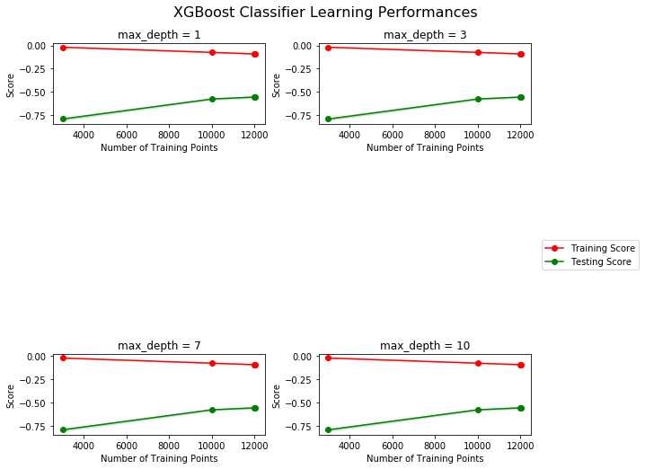

```python
#try the simpler feature set
train_sizes = [3000, 10000, 12000, int(max_train_size)]


#train_sizes = np.linspace(min_train_size, max_train_size, num=5, endpoint=True)

ModelLearning(X_train[TEXT_COLUMN], y_train, 5, train_sizes, bestpipelinemodel)
```

```python
X_train.shape
```

```
(20080, 4)
```

```python
y_train.shape
```

```
(20080,)
```

```
[-0.6626694  -0.3371863  -0.19652949]
[0.00281895 0.00244067 0.00207616]
[-0.92243491 -0.68449793 -0.58276018]
[0.01437683 0.01290981 0.01285827]
```

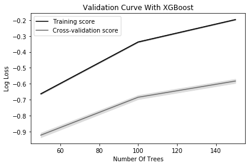

```python
from sklearn.model_selection import validation_curve
X =  X_train[TEXT_COLUMN]
y = y_train

param_range = np.arange(50, 200, 50)
train_scores, test_scores = validation_curve( bestpipelinemodel,
                                             X,
                                             y,
                                             param_name="clf__n_estimators",
                                             param_range=param_range,
                                             cv=5,
                                             scoring="neg_log_loss",
                                             n_jobs=-1)


# Calculate mean and standard deviation for training set scores
train_mean = np.mean(train_scores, axis=1)
train_std = np.std(train_scores, axis=1)

print(train_mean)
print(train_std)

# Calculate mean and standard deviation for test set scores
test_mean = np.mean(test_scores, axis=1)
test_std = np.std(test_scores, axis=1)

print(test_mean)
print(test_std)

# Plot mean accuracy scores for training and test sets
plt.plot(param_range, train_mean, label="Training score", color="black")
plt.plot(param_range, test_mean, label="Cross-validation score", color="dimgrey")

# Plot accurancy bands for training and test sets
plt.fill_between(param_range, train_mean - train_std, train_mean + train_std, color="gray")
plt.fill_between(param_range, test_mean - test_std, test_mean + test_std, color="gainsboro")

# Create plot
plt.title("Validation Curve With XGBoost")
plt.xlabel("Number Of Trees")
plt.ylabel("Log Loss")
plt.tight_layout()
plt.legend(loc="best")
plt.show()
```

```
[[-1.09092928 -1.0913082  -1.09107551 -1.09466921 -1.09938067]
 [-0.45701391 -0.46207229 -0.46252791 -0.46444337 -0.46296904]
 [-0.11975293 -0.12325519 -0.12329609 -0.12268499 -0.12081758]
 [-0.01995051 -0.02023987 -0.02106029 -0.02091974 -0.02077284]
 [-0.00854678 -0.00861066 -0.00879274 -0.00872349 -0.00874044]]
[[-1.1320433  -1.13132682 -1.13054905 -1.116603   -1.10831923]
 [-0.68438815 -0.67292795 -0.67361377 -0.655428   -0.6565363 ]
 [-0.54464922 -0.52844242 -0.53040491 -0.50828699 -0.51953135]
 [-0.5073939  -0.49574554 -0.49967796 -0.46920677 -0.48208734]
 [-0.51750181 -0.51082301 -0.5079587  -0.48071198 -0.48672318]]
[-1.09347257 -0.46180531 -0.12196136 -0.02058865 -0.00868282]
[3.26301451e-03 2.52446137e-03 1.42580148e-03 4.23051221e-04
 9.02991690e-05]
[-1.12376828 -0.66857883 -0.52626298 -0.4908223  -0.50074374]
[0.00960834 0.01106496 0.01206988 0.01357063 0.01436891]
```

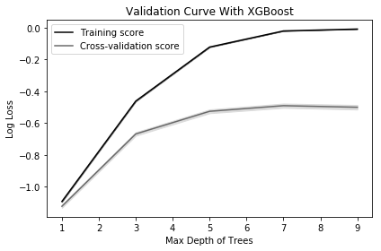

```python
from sklearn.model_selection import validation_curve
X =  X_train[TEXT_COLUMN]
y = y_train

param_range = np.arange(1, 10, 2)
train_scores, test_scores = validation_curve( bestpipelinemodel,
                                             X,
                                             y,
                                             param_name="clf__max_depth",
                                             param_range=param_range,
                                             cv=5,
                                             scoring="neg_log_loss",
                                             n_jobs=-1)

print(train_scores)
print(test_scores)
# Calculate mean and standard deviation for training set scores
train_mean = np.mean(train_scores, axis=1)
train_std = np.std(train_scores, axis=1)

print(train_mean)
print(train_std)

# Calculate mean and standard deviation for test set scores
test_mean = np.mean(test_scores, axis=1)
test_std = np.std(test_scores, axis=1)

print(test_mean)
print(test_std)

# Plot mean accuracy scores for training and test sets
plt.plot(param_range, train_mean, label="Training score", color="black")
plt.plot(param_range, test_mean, label="Cross-validation score", color="dimgrey")

# Plot accurancy bands for training and test sets
plt.fill_between(param_range, train_mean - train_std, train_mean + train_std, color="gray")
plt.fill_between(param_range, test_mean - test_std, test_mean + test_std, color="gainsboro")

# Create plot
plt.title("Validation Curve With XGBoost")
plt.xlabel("Max Depth of Trees")
plt.ylabel("Log Loss")
plt.tight_layout()
plt.legend(loc="best")
plt.show()
```

```python
#Check the impact of the learning rate on the model
```

```
[-2.44677604 -2.1803648  -1.19099218 -0.12196136 -0.02096148 -0.00647697]
[9.14354839e-05 9.38129855e-04 3.05838942e-03 1.42580148e-03
 2.51559520e-04 1.54923065e-04]
[-2.44992031 -2.20707336 -1.33959658 -0.52626298 -0.44573862 -0.43720429]
[0.00030315 0.0018284  0.01014737 0.01206988 0.00945682 0.00804649]
```

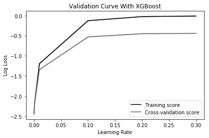

```python
from sklearn.model_selection import validation_curve
X =  X_train[TEXT_COLUMN]
y = y_train

param_range = [0.0001, 0.001, 0.01, 0.1, 0.2, 0.3]
train_scores, test_scores = validation_curve( bestpipelinemodel,
                                             X,
                                             y,
                                             param_name="clf__learning_rate",
                                             param_range=param_range,
                                             cv=5,
                                             scoring="neg_log_loss",
                                             n_jobs=-1)


# Calculate mean and standard deviation for training set scores
train_mean = np.mean(train_scores, axis=1)
train_std = np.std(train_scores, axis=1)

print(train_mean)
print(train_std)

# Calculate mean and standard deviation for test set scores
test_mean = np.mean(test_scores, axis=1)
test_std = np.std(test_scores, axis=1)

print(test_mean)
print(test_std)

# Plot mean accuracy scores for training and test sets
plt.plot(param_range, train_mean, label="Training score", color="black")
plt.plot(param_range, test_mean, label="Cross-validation score", color="dimgrey")

# Plot accurancy bands for training and test sets
plt.fill_between(param_range, train_mean - train_std, train_mean + train_std, color="gray")
plt.fill_between(param_range, test_mean - test_std, test_mean + test_std, color="gainsboro")

# Create plot
plt.title("Validation Curve With XGBoost")
plt.xlabel("Learning Rate")
plt.ylabel("Log Loss")
plt.tight_layout()
plt.legend(loc="best")
plt.show()
```

```python
joblib_file = "joblib_best_xgb_text2.pkl"
```

```python
bestpipeline2 = Pipeline([
    ('vect', CountVectorizer(max_df=0.5, max_features=300, ngram_range=(1,3))),
     ('clf', xgb.XGBClassifier(n_estimators = 100, max_depth=5, reg_alpha=0.01,  eval_metric='logloss', learning_rate=0.1, early_stopping_rounds=10)),
])





# Make prediction for test data
```

```python
#fit pipeline to training data
bestpipelinemodel2 = bestpipeline2.fit(X_train[TEXT_COLUMN], y_train)
joblib.dump(bestpipeline2, joblib_file)
```

```
['joblib_best_xgb_text2.pkl']
```

```python
joblib_model = joblib.load(joblib_file)
```

```python
bestpipeline_predictions2 = joblib_model.predict_proba(X_test[TEXT_COLUMN])
```

```python
sig_score = log_loss(y_test, bestpipeline_predictions2)
print(sig_score)
```

```
0.6714234559781819
```

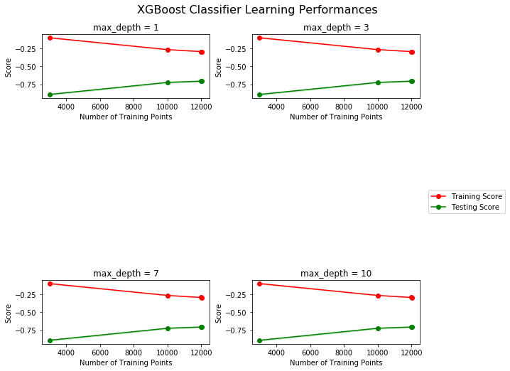

```python
train_sizes = [3000, 10000, 12000, int(max_train_size)]


ModelLearning(X_train[TEXT_COLUMN], y_train, 5, train_sizes, joblib_model)
```